# Classification with Imbalanced Classes

## **Classification with Imbalanced Classes** **by Mehdi Rezvandehy**

Summary

It is common for binary classification you get total accuracy above 90%; however, when you apply a random classifier, you still get close 90% accuracy. This is because of imbalanced class: 90% of one class and 10% of another class. This leads to very low accuracy for rare class that causes a lot of frustration even if you apply a very powerful technique. There some techniques to resolve this problem. In this work, three techniques will be discussed.

**Customer** churn from [Kaggle](https://www.kaggle.com/barelydedicated/bank-customer-churn-modeling/version/1) is applied here. Customer churn is a financial expression referring to losing of a customer or client when a customer abandons interaction with business or company.

The classifier for this study is **Random Forest (RF)** that is among the most versatile and reliable machine learning algorithms for non-linear and complex data. The RF randomly creates and merges multiple decision trees and predicts a class that gets the most votes among all trees. Despite its simplicity, RF is one of the most powerful ML algorithms available today.

A binary classification will be applied by RF as below:

- The irrelevant features are removed from data.
- The data set is divided into 80% training set and 20% test set.
- Data processing is applied for training set including imputation of missing values, normalization and text handling.
- Train RF algorithm using the training set by implementing a binary classification.
- The trained model is applied to predict test set.

Three approaches are considered for classification for imbalanced classes:

**1- Oversampling**

**2- Undersampling**

**3- Reliable Threshold with Bootstrapping**

The performance of these techniques are compared with never before seen data set (test set). More details of those techniques will be discussed.

# Table of Contents

Required Python Libraries

```python
import os
import pandas as pd
import matplotlib as mpl
import matplotlib.pyplot as plt
import numpy as np
from sklearn.preprocessing import OneHotEncoder
from sklearn.model_selection import train_test_split
import time
import zipfile
from IPython.display import HTML
from IPython.display import display, Math, Latex
import pickle
from matplotlib.offsetbox import AnchoredText
from matplotlib.ticker import PercentFormatter
from sklearn.model_selection import StratifiedShuffleSplit
from sklearn.preprocessing import OrdinalEncoder
from sklearn.preprocessing import StandardScaler
from sklearn.model_selection import cross_val_score
from sklearn.model_selection import cross_val_predict
from sklearn.metrics import accuracy_score
from sklearn.dummy import DummyClassifier
from sklearn.linear_model import SGDClassifier
from sklearn.linear_model import LogisticRegression
from sklearn.ensemble import RandomForestClassifier
from sklearn.model_selection import StratifiedShuffleSplit
from sklearn.metrics import recall_score
import logging
from matplotlib import gridspec
import matplotlib.patheffects as pe
import matplotlib.ticker as mtick
import matplotlib.pyplot as plt
from sklearn.metrics import roc_curve, auc
from sklearn.cluster import KMeans
from scipy.stats import mode
from sklearn.metrics import precision_recall_curve
#!pip install imbalanced-learn
# version number
import imblearn
import warnings
warnings.filterwarnings('ignore')
```

# Data Processing

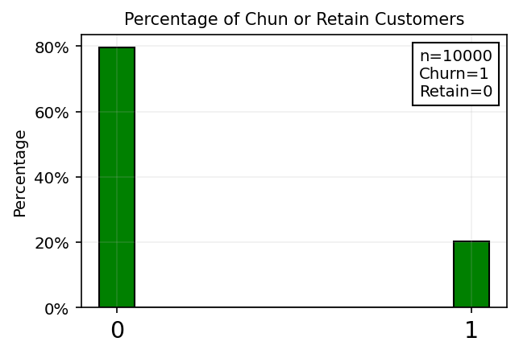

```python
# Read data 'Churn_Modelling.csv'
df = pd.read_csv('Churn_Modelling.csv')

# Shuffle the data
np.random.seed(32)
df=df.reindex(np.random.permutation(df.index))
df.reset_index(inplace=True, drop=True) # Reset index

# Remove 'RowNumber','CustomerId','Surname' features that are un
df=df.drop(['RowNumber','CustomerId','Surname'],axis=1,inplace=False)

# Divide Data into Training set (80%) and Test set (20%)
font = {'size'   : 9.5}
plt.rc('font', **font)
fig = plt.subplots(figsize=(10, 3), dpi= 150, facecolor='w', edgecolor='k')
ax1=plt.subplot(1,2,1)
histplt(df['Exited'],bins=5,title="Percentage of Chun or Retain Customers",xlabl="",xlimt=(-0.1,1.1),axt=ax1)
plt.show()
```

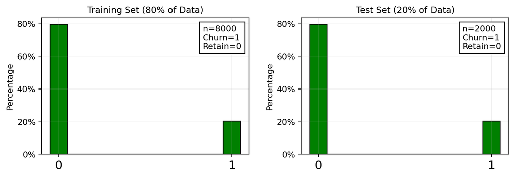

```python
# Training and Test
spt = StratifiedShuffleSplit(n_splits=1, test_size=0.2, random_state=42)
for train_idx, test_idx in spt.split(df, df['Exited']):
    train_set_strat = df.loc[train_idx]
    test_set_strat  = df.loc[test_idx]

train_set_strat.reset_index(inplace=True, drop=True) # Reset index
test_set_strat.reset_index(inplace=True, drop=True) # Reset index

font = {'size'   : 10}
plt.rc('font', **font)

fig = plt.subplots(figsize=(10, 3), dpi= 160, facecolor='w', edgecolor='k')

ax1=plt.subplot(1,2,1)
val=train_set_strat['Exited']
histplt(val,bins=14,title="Training Set (80% of Data)",xlabl="",xlimt=(-0.1,1.1),axt=ax1)

ax2=plt.subplot(1,2,2)
val=test_set_strat['Exited']
histplt(val,bins=14,title="Test Set (20% of Data)",xlabl="",xlimt=(-0.1,1.1),axt=ax2)

plt.subplots_adjust(wspace=0.25)
plt.show()
```

```python
################### Data Processing for training set ######################

# Text Handeling
# Convert Geography to one-hot-encoding
Geog_1hot=pd.get_dummies(train_set_strat['Geography'],prefix='Geography')

# Convert gender to 0 and 1
ordinal_encoder = OrdinalEncoder()
train_set_strat['Gender'] = ordinal_encoder.fit_transform(train_set_strat[['Gender']])

# Remove 'Geography'
train_set_strat=train_set_strat.drop(['Geography'],axis=1,inplace=False)
train_set_strat=pd.concat([Geog_1hot,train_set_strat], axis=1) # Concatenate rows
```

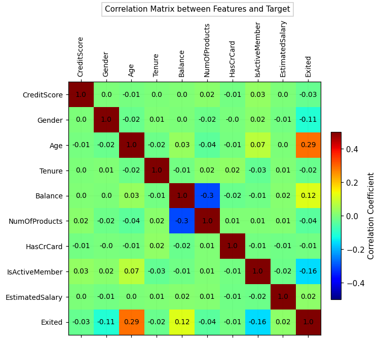

```python
# Correlation matrix
font = {'size'   : 10}
plt.rc('font', **font)
fig, ax=plt.subplots(figsize=(6, 6), dpi= 110, facecolor='w', edgecolor='k')

df_tmp=train_set_strat.drop(['Geography_France','Geography_Germany','Geography_Spain'], axis=1)
colmn=list(df_tmp.columns)
corr=np.zeros((len(colmn),len(colmn)))

for l in range(len(colmn)):
    for l1 in range(len(colmn)):
        cc=np.corrcoef(df_tmp[colmn[l]],df_tmp[colmn[l1]])
        corr[l,l1]=cc[0,1]
        ax.text(l, l1, str(round(cc[0,1],2)), va='center', ha='center',fontsize=9)

im =ax.matshow(corr, cmap='jet', interpolation='nearest',vmin=-0.5, vmax=0.5)

cbaxes = fig.add_axes([0.92, 0.23, 0.03, 0.50])
cbar =fig.colorbar(im,cax=cbaxes,shrink=0.5,label='Correlation Coefficient')
cbar.ax.tick_params(labelsize=10)

ax.set_xticks(np.arange(len(corr)))
ax.set_xticklabels(colmn,fontsize=9, rotation=90)
ax.set_yticks(np.arange(len(corr)))
ax.set_yticklabels(colmn,fontsize=9)
ax.grid(color='k', linestyle='-', linewidth=0.025)
plt.text(-23,1.22,'Correlation Matrix between Features and Target',
         fontsize=10,bbox=dict(facecolor='white', alpha=0.2))
plt.show()
```

```python
df_tmp.corr()
```

|  | CreditScore | Gender | Age | Tenure | Balance | NumOfProducts | HasCrCard | IsActiveMember | EstimatedSalary | Exited |
| --- | --- | --- | --- | --- | --- | --- | --- | --- | --- | --- |
| CreditScore | 1.000000 | 0.001433 | -0.005420 | 0.001521 | 0.003992 | 0.016401 | -0.008785 | 0.027449 | 0.001323 | -0.026875 |
| Gender | 0.001433 | 1.000000 | -0.022315 | 0.006523 | 0.003258 | -0.019270 | -0.000039 | 0.017599 | -0.010519 | -0.109093 |
| Age | -0.005420 | -0.022315 | 1.000000 | -0.018628 | 0.034488 | -0.036873 | -0.007411 | 0.074704 | 0.000661 | 0.291995 |
| Tenure | 0.001521 | 0.006523 | -0.018628 | 1.000000 | -0.009102 | 0.018458 | 0.023652 | -0.028612 | 0.006609 | -0.021934 |
| Balance | 0.003992 | 0.003258 | 0.034488 | -0.009102 | 1.000000 | -0.300783 | -0.019790 | -0.014346 | 0.015004 | 0.120064 |
| NumOfProducts | 0.016401 | -0.019270 | -0.036873 | 0.018458 | -0.300783 | 1.000000 | 0.005619 | 0.007150 | 0.010176 | -0.040284 |
| HasCrCard | -0.008785 | -0.000039 | -0.007411 | 0.023652 | -0.019790 | 0.005619 | 1.000000 | -0.007998 | -0.014319 | -0.008724 |
| IsActiveMember | 0.027449 | 0.017599 | 0.074704 | -0.028612 | -0.014346 | 0.007150 | -0.007998 | 1.000000 | -0.017699 | -0.157265 |
| EstimatedSalary | 0.001323 | -0.010519 | 0.000661 | 0.006609 | 0.015004 | 0.010176 | -0.014319 | -0.017699 | 1.000000 | 0.019957 |
| Exited | -0.026875 | -0.109093 | 0.291995 | -0.021934 | 0.120064 | -0.040284 | -0.008724 | -0.157265 | 0.019957 | 1.000000 |

Figure below show correlation between training features and target feature (Exited). Age has positive correlation and IsActiveMember has negative correlation with target (`Exited`). Other Features are not linearly correlated with the target (`Exited`).

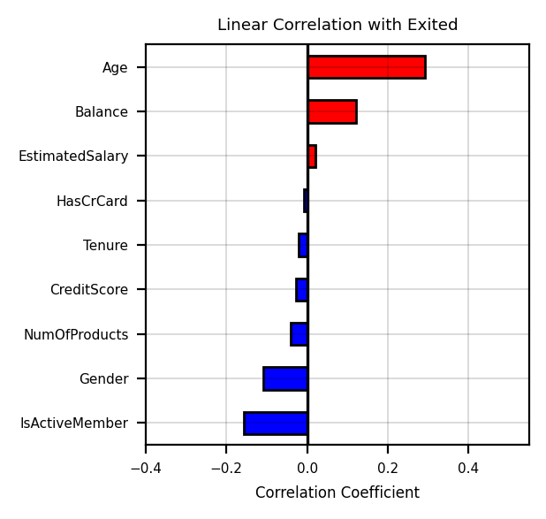

```python
font = {'size'   : 5.5}
plt.rc('font', **font)
ax1 = plt.subplots(figsize=(2.8, 3), dpi= 200, facecolor='w', edgecolor='k')

# Plot correlations of attributes with the last column
corr_bar(df_tmp,title='Linear Correlation with Exited')
```

```python
# Standardization
# Make training features and target
X_train = train_set_strat.drop("Exited", axis=1)
y_train = train_set_strat["Exited"].values

# Divide into two training sets (with and without standization)
clmn=['Geography_France','Geography_Germany','Geography_Spain',
                               'Gender','NumOfProducts','HasCrCard','IsActiveMember']
X_train_for_std = X_train.drop(clmn, axis=1)
X_train_not_std =X_train[clmn]
features_colums=list(X_train_for_std.columns)+list(X_train_not_std.columns)
#
scaler = StandardScaler()
scaler.fit(X_train_for_std)
#
df_train_std=scaler.transform(X_train_for_std)
X_train_std=np.concatenate((df_train_std,X_train_not_std), axis=1)
```

# Random Forest

```python
# Random Forest for taining set
rnd = RandomForestClassifier(n_estimators=50, max_depth= 25, min_samples_split= 20, bootstrap= True, random_state=42)
rnd.fit(X_train_std,y_train)
y_train_pred=cross_val_predict(rnd,X_train_std,y_train, cv=3)
y_train_proba_rnd=cross_val_predict(rnd,X_train_std,y_train, cv=3, method='predict_proba')

################### Data Processing for test set  ######################
# Convert Geography to one-hot-encoding
Geog_1hot=pd.get_dummies(test_set_strat['Geography'],prefix='Geography')

# Convert gender to 0 and 1
ordinal_encoder = OrdinalEncoder()
test_set_strat['Gender'] = ordinal_encoder.fit_transform(test_set_strat[['Gender']])

# Remove 'Geography'
test_set_strat=test_set_strat.drop(['Geography'],axis=1,inplace=False)
test_set_strat=pd.concat([Geog_1hot,test_set_strat], axis=1) # Concatenate rows

# Standardize data
X_test = test_set_strat.drop("Exited", axis=1)
y_test = test_set_strat["Exited"].values
#
clmn=['Geography_France','Geography_Germany','Geography_Spain',
                               'Gender','NumOfProducts','HasCrCard','IsActiveMember']
X_test_for_std =  X_test.drop(clmn, axis=1)
X_test_not_std =  X_test[clmn]
features_colums=list(X_test_for_std.columns)+list(X_test_not_std.columns)
#
df_test_std=scaler.transform(X_test_for_std)
X_test_std=np.concatenate((df_test_std,X_test_not_std), axis=1)

# Random Forest for test set
y_test_pred=rnd.predict(X_test_std)
y_test_proba_rnd=rnd.predict_proba(X_test_std)
```

The most common approach for assessment of classification is accuracy, which is calculated by number of true predicted over total number of data. However, accuracy alone may not be practical for performance measurement of classifiers, especially in cease of imbalanced datasets. Accuracy should be considered along with other metrics. Confusion matrix is a much better way to evaluate the performance of a classifier. The general idea is to consider the number of times instances of negative class are misclassified as positive class and vice versa. Three more metrics Sensitivity, Precision and Specificity can be calculated as well as Accuracy:

**Accuracy=(𝑇𝑃+𝑇𝑁)/(𝑇𝑃+𝑇𝑁+𝐹𝑃+𝐹𝑁):** Accuracy is simply the fraction of the total samples that is correctly identified.

**Sensitivity (Recall)= 𝑇𝑃/(𝑇𝑃+𝐹𝑁):** Sensitivity is the proportion of correct positive predictions to the total positive classes.

**Precision= 𝑇𝑃/(𝑇𝑃+𝐹𝑃):** Precision is the proportion of correct positive prediction to the total predicted values.

**Specificity= 𝑇𝑁/(𝑇𝑁+𝐹𝑃)** Specificity is the true negative rate or the proportion of negatives that are correctly identified.

**TP:** True Positives, **FP:** False Positives, **FN:** False Negatives, **TN:** True Negatives

The Figure below shows these metrics calculated for training and test set.

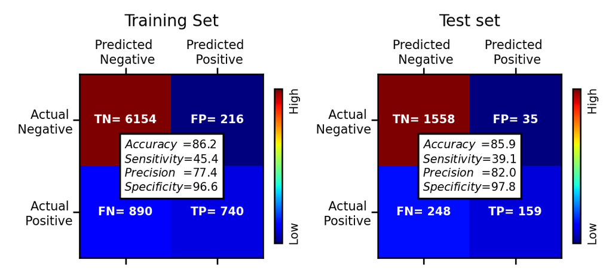

```python
font = {'size'   : 6}
plt.rc('font', **font)
fig = plt.subplots(figsize=(5, 5), dpi= 250, facecolor='w', edgecolor='k')
ax1=plt.subplot(1,2,1)
_,_,_,_=Conf_Matrix(y_train,y_train_pred,axt=ax1, title='Training Set')
ax1=plt.subplot(1,2,2)
_,_,_,_=Conf_Matrix(y_test,y_test_pred,axt=ax1, title='Test set')

plt.subplots_adjust(wspace=0.3)
```

The receiver operating characteristic (ROC) curve is another common tool used with binary classifiers. It is very similar to the precision/recall curve, but instead of plotting precision versus recall, the ROC curve plots the true positive rate (another name for recall) against the false positive rate. The FPR is the ratio of negative instances that are incorrectly classified as positive. It is equal to one minus the true negative rate, which is the ratio of negative instances that are correctly classified as negative. The TNR is also called specificity. **Hence the ROC curve plots sensitivity (recall) versus 1 – specificity.**

For more information and details about ROC, see ROC)

**Thus every point on the ROC curve represents a chosen cut-off even though you cannot see this cut-off. What you can see is the true positive fraction and the false positive fraction that you will get when you choose this cut-off.**

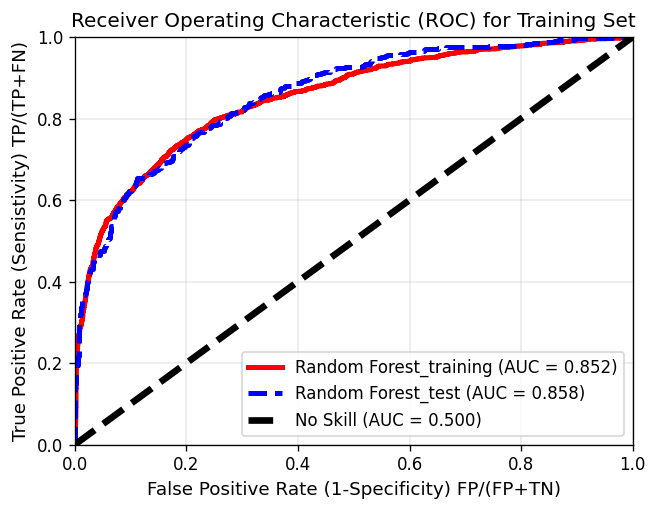

```python
font = {'size' : 10}
plt.rc('font', **font)
fig = plt.subplots(figsize=(6,4.5), dpi= 120, facecolor='w', edgecolor='k')

# Random Forest for taining
y=y_train
pred=y_train_proba_rnd[:,1]
fpr, tpr, thresold = roc_curve(y, pred)
roc_auc = auc(fpr, tpr)
#plt.scatter(fpr, tpr,s=10,c=thresold,linewidths=0,cmap='gray',vmin=0, vmax=1)
plt.plot(fpr, tpr,'r', linewidth=3,label='Random Forest_training (AUC = %0.3f)' % roc_auc)

# Random Forest for test set
y=y_test
pred=y_test_proba_rnd[:,1]
fpr, tpr, thresold = roc_curve(y, pred)
roc_auc = auc(fpr, tpr)
#plt.scatter(fpr, tpr,s=10,c=thresold,linewidths=0,cmap='gray',vmin=0, vmax=1)
plt.plot(fpr, tpr,'b--', linewidth=3,label='Random Forest_test (AUC = %0.3f)' % roc_auc)


# Random Classifier
ns_probs = [1 for _ in range(len(y))]
ns_fpr, ns_tpr, _ = roc_curve(y, ns_probs)
roc_auc = auc(ns_fpr, ns_tpr)
# plot the roc curve for the model
plt.plot(ns_fpr, ns_tpr, 'k--', linewidth=4,label='No Skill (AUC = %0.3f)' % roc_auc)
plt.xlim([0.0, 1.0])
plt.ylim([0.0, 1.0])
plt.xlabel('False Positive Rate (1-Specificity) FP/(FP+TN)',fontsize=11)
plt.ylabel('True Positive Rate (Sensistivity) TP/(TP+FN)',fontsize=11)
plt.title('Receiver Operating Characteristic (ROC) for Training Set',fontsize=12)
plt.grid(linewidth='0.25')
plt.legend(loc="lower right")

plt.show()
```

# Resampling Dataset

We can change the data set to improve predictive models by resampling techniques:

Copies of instances from the under-represented can been added to data set class called **over-sampling** (or more formally sampling with replacement), or delete instances from the over-represented class, called **under-sampling**. These approaches are often very easy to implement; sickit learn library is applied for over or undersampling.

## Oversampling

```python
from collections import Counter
from sklearn.datasets import make_classification
from imblearn.over_sampling import RandomOverSampler
from imblearn.under_sampling import RandomUnderSampler
```

```python
# Scikit learn oversampling strategy with minority
over_sample = RandomOverSampler(sampling_strategy='minority')
```

This means that if the majority class had 10,000 examples and the minority class had 1000, this approach oversample the minority class to reach 10,000 examples. A floating point value can be specified to indicate the ratio of minority class majority examples in the transformed dataset. For example:

```python
# Oversampling strategy
over_sample = RandomOverSampler(sampling_strategy=0.5)
```

It is always recommend to apply samapling for different ratios of classes. and then compare the performance for each ratio.

### Different Rations

```python
Ratio=np.arange(0.35,1.05,0.05)
Train_Accu=len(Ratio)*[None]
Train_Pre=len(Ratio)*[None]
Train_Rec=len(Ratio)*[None]
Train_Spe=len(Ratio)*[None]
y_proba_rnd=len(Ratio)*[None]

for i in range(len(Ratio)):
    # Oversampling strategy
    oversample = RandomOverSampler(sampling_strategy=Ratio[i])
    over_x, over_y = oversample.fit_resample(X_train_std, y_train)
    #print([k/len(y_train) for k in Counter(over_y).values()])

    # Fit Random Forest classifier
    rnd.fit(over_x, over_y)
    y_train_pred=cross_val_predict(rnd,over_x, over_y, cv=3)
    y_rnd_tmp=cross_val_predict(rnd,over_x, over_y, cv=3, method='predict_proba')
    y_proba_rnd[i]=y_rnd_tmp

    acr, prec, reca, spec=Conf_Matrix(over_y,y_train_pred,axt=ax1,plot=False)
    Train_Accu[i]=acr
    Train_Pre [i]=prec
    Train_Rec [i]=reca
    Train_Spe [i]=spec
```

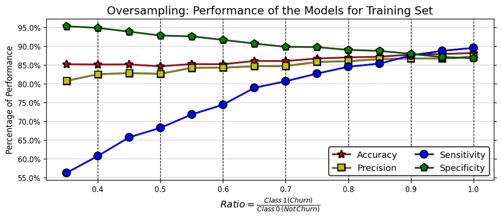

```python
font = {'size'   :9 }
plt.rc('font', **font)

ax2 = ax1.twinx()

fig, ax1 = plt.subplots(figsize=(10, 3.7), dpi= 120, facecolor='w', edgecolor='k')

ax1.plot(Ratio,Train_Accu,'r*-',linewidth=1,path_effects=[pe.Stroke(linewidth=2, foreground='k'), pe.Normal()],
                                                             markersize=10,label='Accuracy',markeredgecolor='k')
ax1.plot(Ratio,Train_Pre,'ys-',linewidth=1,path_effects=[pe.Stroke(linewidth=2, foreground='k'), pe.Normal()],
                                                             markersize=8.0,label='Precision',markeredgecolor='k')
ax1.plot(Ratio,Train_Rec,'bo-',linewidth=2,path_effects=[pe.Stroke(linewidth=2, foreground='k'), pe.Normal()],
                                                             markersize=9,label='Sensitivity',markeredgecolor='k')
ax1.plot(Ratio,Train_Spe,'gp-',linewidth=1,path_effects=[pe.Stroke(linewidth=2, foreground='k'), pe.Normal()],
                                                           markersize=9,label='Specificity',markeredgecolor='k')
#ax1.set_xticks(np.arange(len(Ratio)))
#ax1.set_xticklabels(Ratio,y=0.03, rotation=19)
ax1.xaxis.grid(color='k', linestyle='--', linewidth=0.8)
ax1.yaxis.grid(color='k', linestyle='--', linewidth=0.2)
plt.xlabel(r'$Ratio=\frac{Class\,1 (Churn)}{Class\,0\,(Not\,Churn)}$',fontsize=12)
plt.ylabel('Percentage of Performance',fontsize=10)
plt.title('Oversampling: Performance of the Models for Training Set',fontsize=14)
legend=plt.legend(ncol=2,loc=4,fontsize='11',framealpha =3)
legend.get_frame().set_edgecolor("black")

ax1.yaxis.set_major_formatter(mtick.PercentFormatter(1))
#plt.yticks([0,10,20,30,40,50,60,70,80,90,100],y=0, fontsize=9)
ax1.yaxis.set_ticks_position('both')

#plt.ylim(0.55,0.75)
plt.show()
```

The sensitivity increases by increasing the $Ratio=\frac{Class\,1 (Churn)}{Class\,0\,(Not\,Churn)}$= 0.9 leads to approximately similar accuracy, sensitivity, precision and specificity. So, we use the ratio 0.9 for training.

### Test Set

The trained oversampled model is applied on test set to evaluate the performance on test.

```python
# Oversampling strategy
oversample = RandomOverSampler(sampling_strategy=0.9)

# Apply oversampling on data
over_x, over_y = oversample.fit_resample(X_train_std, y_train)
```

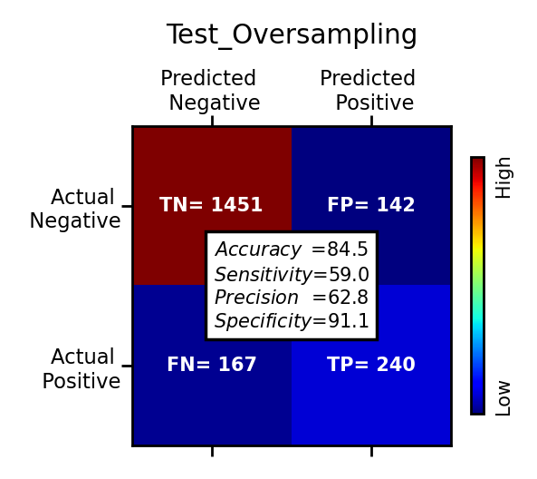

```python
font = {'size'   : 6}
plt.rc('font', **font)
fig = plt.subplots(figsize=(5, 5), dpi= 250, facecolor='w', edgecolor='k')

# Fit Random Forest classifier
rnd.fit(over_x, over_y)
# Random Forest for test set
y_test_pred=rnd.predict(X_test_std)
y_test_proba_rnd=rnd.predict_proba(X_test_std)

ax1=plt.subplot(1,2,1)
Te_Accu_OS,Te_Pre_OS,Te_Rec_OS,Te_Spe_OS=Conf_Matrix(y_test,y_test_pred,axt=ax1,title='Test_Oversampling')
```

## Undersampling

Undersampling may be more reliable for those datasets where we have enough data. **A limitation of undersampling is deleting useful, important, or critical data. Since the examples are deleted randomly, there is no way to detect or retrieve “good” or more information-rich examples from the majority class.**

### Different Rations

```python
Ratio=np.arange(0.35,1.05,0.05)
Train_Accu=len(Ratio)*[None]
Train_Pre=len(Ratio)*[None]
Train_Rec=len(Ratio)*[None]
Train_Spe=len(Ratio)*[None]
y_proba_rnd=len(Ratio)*[None]

for i in range(len(Ratio)):
    # Undersampling strategy
    undersample = RandomUnderSampler(sampling_strategy=Ratio[i],random_state=13)
    under_x, under_y = undersample.fit_resample(X_train_std, y_train)
    #print(Counter(under_y))

    # Fit Random Forest classifier
    rnd.fit(under_x, under_y)
    y_train_pred=cross_val_predict(rnd,under_x, under_y, cv=3)
    y_rnd_tmp=cross_val_predict(rnd,under_x, under_y, cv=3, method='predict_proba')
    y_proba_rnd[i]=y_rnd_tmp

    acr, prec, reca, spec=Conf_Matrix(under_y,y_train_pred,axt=ax1,plot=False)
    Train_Accu[i]=acr
    Train_Pre [i]=prec
    Train_Rec [i]=reca
    Train_Spe [i]=spec
```

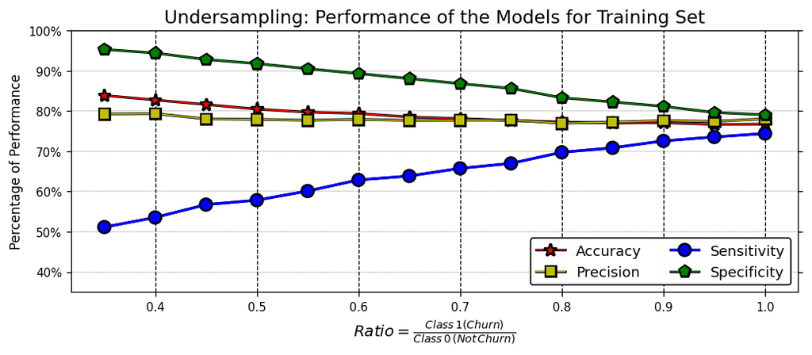

```python
font = {'size'   :9 }
plt.rc('font', **font)

ax2 = ax1.twinx()

fig, ax1 = plt.subplots(figsize=(10, 3.7), dpi= 120, facecolor='w', edgecolor='k')

ax1.plot(Ratio,Train_Accu,'r*-',linewidth=1,path_effects=[pe.Stroke(linewidth=2, foreground='k'), pe.Normal()],
                                                             markersize=10,label='Accuracy',markeredgecolor='k')
ax1.plot(Ratio,Train_Pre,'ys-',linewidth=1,path_effects=[pe.Stroke(linewidth=2, foreground='k'), pe.Normal()],
                                                             markersize=8.0,label='Precision',markeredgecolor='k')
ax1.plot(Ratio,Train_Rec,'bo-',linewidth=2,path_effects=[pe.Stroke(linewidth=2, foreground='k'), pe.Normal()],
                                                             markersize=9,label='Sensitivity',markeredgecolor='k')
ax1.plot(Ratio,Train_Spe,'gp-',linewidth=1,path_effects=[pe.Stroke(linewidth=2, foreground='k'), pe.Normal()],
                                                           markersize=9,label='Specificity',markeredgecolor='k')
ax1.xaxis.grid(color='k', linestyle='--', linewidth=0.8)
ax1.yaxis.grid(color='k', linestyle='--', linewidth=0.2)
plt.xlabel(r'$Ratio=\frac{Class\,1 (Churn)}{Class\,0\,(Not\,Churn)}$',fontsize=12)
plt.ylabel('Percentage of Performance',fontsize=10)
plt.title('Undersampling: Performance of the Models for Training Set',fontsize=14)
legend=plt.legend(ncol=2,loc=4,fontsize='11',framealpha =3)
legend.get_frame().set_edgecolor("black")
ax1.yaxis.set_major_formatter(mtick.PercentFormatter(1))
ax1.yaxis.set_ticks_position('both')

plt.ylim(0.35,1)
plt.show()
```

The sensitivity increases by increasing the ratio $\frac{Class\,1 (Churn)}{Class\,0\,(Not\,Churn)}$; however, compared with oversampling, the performance of the undersampling is lower.

### Test Set

```python
# Oversampling strategy
oversample = RandomUnderSampler(sampling_strategy=0.9)

# Apply oversampling on data
under_x, under_y = undersample.fit_resample(X_train_std, y_train)
```

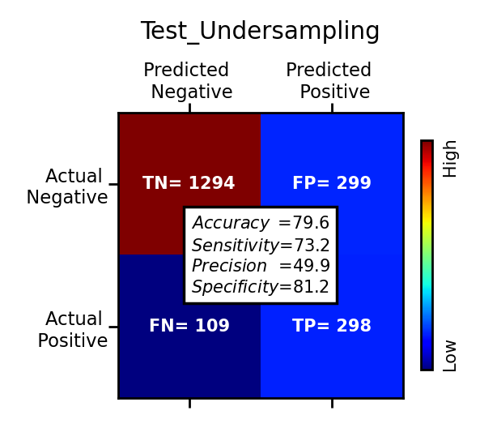

```python
font = {'size'   : 6}
plt.rc('font', **font)
fig = plt.subplots(figsize=(5, 5), dpi= 250, facecolor='w', edgecolor='k')

# Fit Random Forest classifier
rnd.fit(under_x, under_y)
# Random Forest for test set
y_test_pred=rnd.predict(X_test_std)
y_test_proba_rnd=rnd.predict_proba(X_test_std)

ax1=plt.subplot(1,2,1)
Te_Accu_US,Te_Pre_US,Te_Rec_US,Te_Spe_US=Conf_Matrix(y_test,y_test_pred,axt=ax1,title='Test_Undersampling')
```

# Reliable Threshold with Bootstrapping

Instead of manipulating data by oversamplaning or undersampling, we can tweak threshold to make reliable sensitivity or precision.

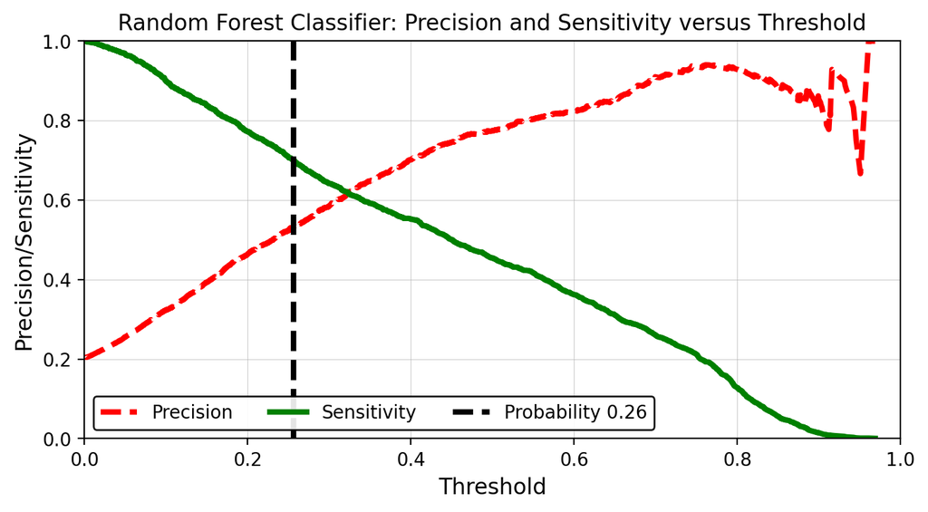

```python
font = {'size' : 10}
plt.rc('font', **font)
fig = plt.subplots(figsize=(8,4), dpi= 200, facecolor='w', edgecolor='k')

pred=y_train_proba_rnd[:,1]
precisions, sensitivity, thresholds = precision_recall_curve(y_train, pred)

# Find a threshold with sensitivity higher than 0.7 and precision higher than 0.5
threshold=np.max(thresholds[np.where((sensitivity>0.7) & (precisions>0.50))])
plot_precision_recall_vs_threshold(precisions, sensitivity, thresholds,x=threshold)
plt.show()
```

However, the threshold is achieved based on training data. In order to get more reliable threshold, we can run a bootstrapping, dividing the data into training set and set. For each run, a model is trained with the training set and applied the trained model on test set to fine an threshold that has required metrics (for example sensitivity>0.7).

```python
acr_out_of_smpl = []
rec_out_of_smpl = []
threshold_=       []

# Apply 100 bootstraping sampling
n_splits=100
boot = StratifiedShuffleSplit(n_splits=n_splits,test_size=0.2, random_state=42)

num = 0
for train_idx, test_idx in boot.split(X_train_std, y_train):

    x_b_train = X_train_std[train_idx]
    y_b_train = y_train[train_idx]
    x_b_test  = X_train_std[test_idx]
    y_b_test  = y_train[test_idx]
    #
    rnd.fit(x_b_train, y_b_train)
    pred = rnd.predict_proba(x_b_test)[:,1]

    precisions, sensitivity, thresholds = precision_recall_curve(y_b_test, pred)

    try:
        num+=1
        # Only find the thresholds that has sensitivity>0.75 and precisions>0.50
        threshold=np.max(thresholds[np.where((sensitivity>0.75) & (precisions>0.50))])
        pred=[1 if i >= threshold else 0 for i in pred]

        acr=accuracy_score(y_b_test, pred)
        reca=recall_score(y_b_test, pred)

        acr_out_of_smpl.append(acr)
        rec_out_of_smpl.append(reca)
        threshold_.append(threshold)
        # Record this
        print('Sample #'+str(num)+', Accuracy='+str(np.round(acr,4))+
              ', Recall='+str(np.round(reca,4)), 'threshold='+str(np.round(threshold,4)))

    except ValueError:
        pass
```

```
Sample #2, Accuracy=0.8138, Recall=0.7515 threshold=0.242
Sample #8, Accuracy=0.8162, Recall=0.7515 threshold=0.2288
Sample #9, Accuracy=0.8, Recall=0.7515 threshold=0.2325
Sample #11, Accuracy=0.8006, Recall=0.7515 threshold=0.2143
Sample #12, Accuracy=0.8006, Recall=0.7515 threshold=0.2254
Sample #17, Accuracy=0.7969, Recall=0.7546 threshold=0.2241
Sample #19, Accuracy=0.8119, Recall=0.7515 threshold=0.2401
Sample #22, Accuracy=0.7975, Recall=0.7515 threshold=0.2212
Sample #25, Accuracy=0.8344, Recall=0.7515 threshold=0.2489
Sample #27, Accuracy=0.7981, Recall=0.7515 threshold=0.2104
Sample #28, Accuracy=0.8162, Recall=0.7515 threshold=0.2404
Sample #37, Accuracy=0.8262, Recall=0.7515 threshold=0.2638
Sample #42, Accuracy=0.8012, Recall=0.7515 threshold=0.2247
Sample #48, Accuracy=0.8381, Recall=0.7515 threshold=0.2487
Sample #49, Accuracy=0.8331, Recall=0.7515 threshold=0.2656
Sample #51, Accuracy=0.8256, Recall=0.7515 threshold=0.2683
Sample #57, Accuracy=0.8, Recall=0.7515 threshold=0.235
Sample #60, Accuracy=0.8119, Recall=0.7515 threshold=0.2537
Sample #62, Accuracy=0.8131, Recall=0.7515 threshold=0.243
Sample #63, Accuracy=0.8206, Recall=0.7515 threshold=0.2266
Sample #65, Accuracy=0.7981, Recall=0.7515 threshold=0.2199
Sample #66, Accuracy=0.805, Recall=0.7515 threshold=0.2268
Sample #72, Accuracy=0.8062, Recall=0.7515 threshold=0.2386
Sample #76, Accuracy=0.8081, Recall=0.7515 threshold=0.2295
Sample #80, Accuracy=0.7981, Recall=0.7515 threshold=0.2222
Sample #86, Accuracy=0.7981, Recall=0.7515 threshold=0.2206
Sample #87, Accuracy=0.7969, Recall=0.7515 threshold=0.2231
Sample #92, Accuracy=0.8044, Recall=0.7515 threshold=0.241
Sample #93, Accuracy=0.8269, Recall=0.7515 threshold=0.2612
Sample #95, Accuracy=0.8212, Recall=0.7515 threshold=0.2604
Sample #97, Accuracy=0.8119, Recall=0.7515 threshold=0.2365
```

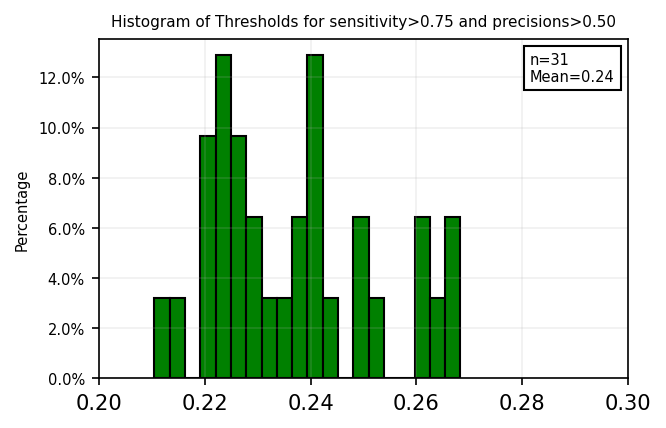

```python
font = {'size'   : 7}
plt.rc('font', **font)
fig = plt.subplots(figsize=(10, 3), dpi= 150, facecolor='w', edgecolor='k')
ax1=plt.subplot(1,2,1)
histplt(threshold_,bins=20,title="Histogram of Thresholds for Sensitivity>0.75 and Precisions>0.50",
        xlabl="",xlimt=(0.2,0.3),axt=ax1, icalss=False)
plt.show()
```

Now calculate the metrics with the optimum threshold for test set. The optimum threshold is 0.24, the average of bootstrapping.

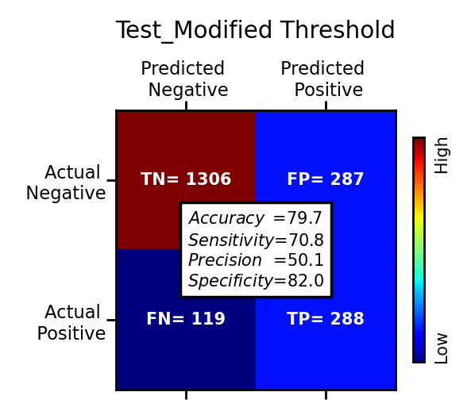

```python
font = {'size'   : 6}
plt.rc('font', **font)
fig = plt.subplots(figsize=(5, 5), dpi= 250, facecolor='w', edgecolor='k')

# Fit Random Forest classifier
rnd.fit(X_train_std,y_train)

# Random Forest for test set
y_test_pred=rnd.predict(X_test_std)
y_test_proba_rnd=rnd.predict_proba(X_test_std)[:,1]

y_p=[1 if i >= np.mean(threshold_) else 0 for i in y_test_proba_rnd]

ax1=plt.subplot(1,2,1)
Te_Accu_MT,Te_Pre_MT,Te_Rec_MT,Te_Spe_MT=Conf_Matrix(y_test,y_p,axt=ax1,title='Test_Modified Threshold')
```

# Appendix (Required Python Functions)

```python
def histplt (val,bins,title,xlabl,xlimt,axt=None,icalss=True):
    """ Function for histogram plotting"""

    ax1 = axt or plt.axes()
    val=np.array(val)
    if(icalss): bins = np.array([-0.05,0.05,0.95,1.05])

    ax1.hist(val, bins=bins, weights=np.ones(len(val)) / len(val),ec='black',color='g')

    n=len(val)
    Mean=np.nanmean(val)
    SD=np.sqrt(np.nanvar(val))
    Max=np.nanmax(val)
    Min=np.nanmin(val)

    if(icalss):
        txt='n=%.0f\nChurn=%.0f\nRetain=%.0f'
        anchored_text = AnchoredText(txt %(n,Max,Min), loc=1)
    else:
        txt='n=%.0f\nMean=%.2f'
        anchored_text = AnchoredText(txt %(n,Mean), loc=1)
    ax1.add_artist(anchored_text)
    plt.title(title,fontsize=font['size']*1.05)
    plt.xlabel(xlabl,fontsize=font['size'])
    ax1.set_ylabel('Percentage',fontsize=font['size'])
    if(icalss):
        ax1.set_xlabel(xlabl,fontsize=font['size']*1.1, labelpad=-13)
    else:
        ax1.set_xlabel(xlabl,fontsize=font['size'], labelpad=-13)

    plt.xlim(xlimt)
    if(icalss): plt.xticks([0,1])
    plt.gca().yaxis.set_major_formatter(PercentFormatter(1))
    ax1.grid(linewidth='0.15')
    ax1.tick_params(axis='x',labelsize='x-large')

#######################################################################

def corr_bar(df,title):
    """Plot correlation bar with the pair of atrribute with last column"""
    corr=df.corr()
    Colms_sh=list(list(corr.columns))
    coefs=corr.values[:,-1][:-1]
    names=Colms_sh[:-1]
    r_ = pd.DataFrame( { 'coef': coefs, 'positive': coefs>=0  }, index = names )
    r_ = r_.sort_values(by=['coef'])
    r_['coef'].plot(kind='barh',edgecolor='black', color=r_['positive'].map({True: 'r', False: 'b'}))
    plt.xlabel('Correlation Coefficient',fontsize=6)
    plt.vlines(x=0,ymin=-0.5, ymax=10, color = 'k',linewidth=1.2)
    plt.title(title)
    plt.xlim((-0.4, 0.55))
    ax1 = plt.gca()
    ax1.xaxis.grid(color='k', linestyle='-', linewidth=0.1)
    ax1.yaxis.grid(color='k', linestyle='-', linewidth=0.1)
    plt.show()

#######################################################################

def Conf_Matrix(y_train,y_train_pred,perfect=0,axt=None,plot=True,title=False):
    '''Plot confusion matrix'''
    from sklearn.metrics import confusion_matrix
    from sklearn.metrics import precision_score, recall_score
    from matplotlib.offsetbox import AnchoredText

    conf_mx=confusion_matrix(y_train,y_train_pred)
    acr=accuracy_score(y_train,y_train_pred)
    conf_mx =confusion_matrix(y_train,y_train_pred)
    prec=precision_score(y_train,y_train_pred) # == TP/(TP+FP)
    reca=recall_score(y_train,y_train_pred) # == TP/(TP+FN) )
    TN=conf_mx[0][0] ; FP=conf_mx[0][1]
    spec= TN/(TN+FP)
    if(plot):
        ax1 = axt or plt.axes()

        if (perfect==1): y_train_pred=y_train

        x=['Predicted \n Negative', 'Predicted \n Positive']; y=['Actual \n Negative', 'Actual \n Positive']
        #row_sums = conf_mx.sum(axis=1, keepdims=True)
        #norm_confmx = (conf_mx / row_sums)*100
        ii=0
        im =ax1.matshow(conf_mx, cmap='jet', interpolation='nearest')
        for (i, j), z in np.ndenumerate(conf_mx):
            if(ii==0): al='TN= '
            if(ii==1): al='FP= '
            if(ii==2): al='FN= '
            if(ii==3): al='TP= '
            ax1.text(j, i, al+'{:0.0f}'.format(z), color='w', ha='center', va='center', fontweight='bold',fontsize=6)
            ii=ii+1

        txt='$ Accuracy\,\,\,$=%.1f\n$Sensitivity$=%.1f\n$Precision\,\,\,\,$=%.1f\n$Specificity$=%.1f'
        anchored_text = AnchoredText(txt %(acr*100,reca*100,prec*100,spec*100), loc=10, borderpad=0)
        ax1.add_artist(anchored_text)

        ax1.set_xticks(np.arange(len(x)))
        ax1.set_xticklabels(x,fontsize=6.5,y=0.97, rotation='horizontal')
        ax1.set_yticks(np.arange(len(y)))
        ax1.set_yticklabels(y,fontsize=6.5,x=0.035, rotation='horizontal')

        #cbaxes = ax1.add_axes([0.92, 0.36, 0.027, 0.25])
        cbar =plt.colorbar(im,shrink=0.3,
                           label='Low                              High',orientation='vertical')
        cbar.set_ticks([])
        plt.title(title,fontsize=8.5,y=1.2)
    return acr, prec, reca, spec

#######################################################################

def plot_precision_recall_vs_threshold(precisions, recalls, thresholds, x=0.8):
    plt.plot(thresholds, precisions[:-1], "r--", label="Precision", linewidth=3)
    plt.plot(thresholds, recalls[:-1], "g-", label="Sensitivity", linewidth=3)
    plt.legend(loc="center right", fontsize=16)
    plt.xlabel("Threshold", fontsize=12)
    plt.ylabel("Precision/Sensitivity", fontsize=12)
    plt.title("Random Forest Classifier: Precision and Sensitivity versus Threshold", fontsize=12)
    plt.grid(linewidth='0.25')
    plt.axvline(x=x,linestyle='--',color='k', linewidth=3,label='Probability '+str(np.round(x,2)))
    plt.legend(loc=3, ncol=3,fontsize=10,markerscale=1.2, edgecolor="black",framealpha=0.9)
    plt.axis([0, 1, 0, 1])
```